# Exploring the Tide-Gauge Data

Author

Fernando Mayer, Niamh Cahill, Niamh Mimnagh

Published

October 10, 2026

## Introduction

This page provides an exploratory analysis of the combined Irish tide-gauge dataset containing observations from the Marine Institute (MI) and the Office of Public Works (OPW).

The purpose of this stage is to understand the observational data available before any tidal harmonic or statistical modelling is performed. In particular, the analysis examines:

- the stations and observations contributed by MI and OPW;
- the spatial and temporal coverage of the combined network;
- sampling frequencies and changes in recording frequency;
- gaps and completeness of the time series;
- the distribution and range of observed water levels;
- quality-control information;
- station metadata, including coordinates and datum information; and
- which stations have sufficient data for the subsequent tidal analysis.

Importantly, the duration of a station record and its completeness are treated as separate properties. A station may span several years while still containing substantial periods of missing observations. The annual completeness summaries therefore provide additional information that should be considered when constructing the three-year, five-year and longer analysis windows used later in the project.

At this stage no observations are inserted to fill gaps, no missing water levels are predicted, and no tidal harmonic models are fitted. Those steps belong to the subsequent data-processing and tidal-analysis stages.

The outputs from this page provide the basis for deciding which observations and stations should proceed to that analysis.

```r
library(arrow)
library(tidyverse)
library(lubridate)
library(patchwork)

here::i_am("index.qmd")

theme_set(
  theme_bw() +
    theme(legend.position = "top", legend.direction = "horizontal"))

dir.create(here::here("outputs"), recursive = TRUE, showWarnings = FALSE)
dir.create(here::here("rds"), recursive = TRUE, showWarnings = FALSE)
```

```r
fl <- here::here("data", "merged_tide_gauge_data", "iteration_a_qc1")
da_arrow <- open_dataset(fl, format = "parquet")
```

The analysis below uses the combined quality-controlled dataset. Therefore, unless otherwise stated, all observations shown on this page have already passed the QC procedure.

```r
vars_required <- c("time", "station_id", "st_id", "latitude", "longitude", "Water_Level_OD_Malin", "QC_Flag")
vars_optional <- c("source", "data_source", "provider", "network", "source_station_code", "source_station_id", "datum", "datum_status")

vars_keep <- intersect(c(vars_required, vars_optional), names(da_arrow))

da <- da_arrow |>
  select(all_of(vars_keep)) |>
  collect()

if (!"st_id" %in% names(da)) {
  da <- da |>
    mutate(st_id = gsub(" ", "", station_id))
}

source_candidates <- c("source", "data_source", "provider", "network")
source_col <- source_candidates[source_candidates %in% names(da)][1]

if (is.na(source_col)) {
  stop(paste0("No MI/OPW source column was found. ", "Expected one of: ", paste(source_candidates, collapse = ", "), ". Add the appropriate source column name to source_candidates."))
}

if (source_col != "source") {
  da <- da |>
    rename(source = all_of(source_col))
}

da <- da |>
  mutate(
    source = case_when(
      str_detect(str_to_upper(as.character(source)), "MI") ~ "MI",
      str_detect(str_to_upper(as.character(source)), "OPW") ~ "OPW",
      TRUE ~ as.character(source) ), source = factor(source)) |>
  arrange(st_id, time)
```

## Dataset overview

The first stage summarises the overall size and structure of the combined dataset.

```r
dataset_summary <- tibble(
  statistic = c("Number of observations", "Number of stations", "First observation", "Last observation"),
  value = c(format(nrow(da), big.mark = ","), n_distinct(da$st_id), as.character(min(da$time, na.rm = TRUE)), as.character(max(da$time, na.rm = TRUE))))

dataset_summary |>
  knitr::kable(col.names = c("Statistic","Value"))
```

| Statistic | Value |
| --- | --- |
| Number of observations | 29,303,019 |
| Number of stations | 42 |
| First observation | 1999-11-02 16:00:00 |
| Last observation | 2025-01-24 02:15:00 |

```r
source_date_range <- da |>
  group_by(source) |>
  summarise(
    first_obs = min(time, na.rm = TRUE),
    last_obs = max(time, na.rm = TRUE),
    n_observations = n(),
    n_stations = n_distinct(st_id), .groups = "drop")
```

## MI and OPW contributions

The combined dataset contains observations supplied by two tide-gauge networks. It is therefore important to understand the contribution made by each source before analysing the records as a single dataset.

```r
source_summary <- da |>
  group_by(source) |>
  summarise(
    n_observations = n(),
    n_stations = n_distinct(st_id),
    first_obs = min(time, na.rm = TRUE),
    last_obs = max(time, na.rm = TRUE),
    .groups = "drop") |>
  mutate(percent_observations = 100 * n_observations / sum(n_observations))

source_summary |>
  knitr::kable(digits = 2, format.args = list(big.mark = ","))
```

| source | n_observations | n_stations | first_obs | last_obs | percent_observations |
| --- | --- | --- | --- | --- | --- |
| MI | 16,940,160 | 23 | 2006-12-06 14:15:00 | 2024-10-23 13:05:00 | 57.81 |
| OPW | 12,362,859 | 20 | 1999-11-02 16:00:00 | 2025-01-24 02:15:00 | 42.19 |

## Duplicate Stations

```r
station_source_overlap <- da |>
  distinct(st_id, source) |>
  count(st_id, name = "n_sources") |>
  filter(n_sources > 1)


## Investigate duplicate sources for MalinHead-PortmorePier
da |>
  filter(st_id == "MalinHead-PortmorePier") |>
  arrange(source, time) |>
  group_by(source) |>
  summarise(
    station_id = first(station_id),
    first_obs = min(time, na.rm = TRUE),
    last_obs = max(time, na.rm = TRUE),
    n_observations = n(),
    n_unique_times = n_distinct(time),
    latitude = first(latitude),
    longitude = first(longitude),
    .groups = "drop")|>
    knitr::kable()
```

| source | station_id | first_obs | last_obs | n_observations | n_unique_times | latitude | longitude |
| --- | --- | --- | --- | --- | --- | --- | --- |
| MI | Malin Head - Portmore Pier | 2008-11-13 15:06:00 | 2024-10-03 14:50:00 | 1150807 | 1150807 | 55.3716 | -7.3347 |
| OPW | Malin Head - Portmore Pier | 2004-01-09 00:15:00 | 2008-03-12 08:00:00 | 411988 | 411988 | 55.3716 | -7.3347 |

## Geographic Distribution of Tide Gauge Stations

The following plot presents the geographic distribution of Irish tide gauge stations, coloured according to their source (MI or OPW).

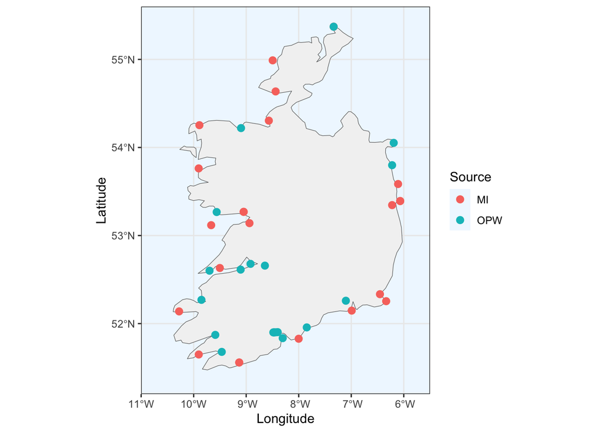

```r
ireland <- rnaturalearth::ne_countries(scale = "medium", country = "Ireland", returnclass = "sf")

station_locations <- da |>
  filter(!is.na(latitude), !is.na(longitude)) |>
  group_by(source, st_id, station_id) |>
  summarise(latitude = first(latitude), longitude = first(longitude), .groups = "drop") |>
  sf::st_as_sf(coords = c("longitude", "latitude"), crs = 4326)

ggplot() +
  geom_sf(data = ireland, fill = "grey95", colour = "grey40") +
  geom_sf(data = station_locations, aes(colour = source), size = 2.5) +
  coord_sf(xlim = c(-11, -5.5), ylim = c(51.2, 55.6), expand = FALSE) +
  labs(x = "Longitude", y = "Latitude", colour = "Source") +
  theme_bw()+
  theme(panel.background = element_rect(fill = "aliceblue", colour = NA))
```

## Temporal coverage

The duration of a tide-gauge record alone does not describe how much information is available. The first analysis therefore examines the beginning, end and total span of the record at each station.

```r
MIN_RECORD_YEARS <- 3

station_coverage <- da |>
  group_by(source, st_id, station_id) |>
  summarise(first_obs = min(time, na.rm = TRUE), last_obs = max(time, na.rm = TRUE), n_observations = n(),.groups = "drop") |>
  mutate(
    record_days = as.numeric(difftime(last_obs, first_obs, units = "days")),
    record_years = record_days / 365.25,
    include_analysis = record_years >= MIN_RECORD_YEARS,
    exclusion_reason = if_else(include_analysis, NA_character_, "Less than 3 years of available data")) |>
  arrange(record_years)


station_coverage |>
  knitr::kable(digits = 2, format = "html", format.args = list(big.mark = ",")) |>
  kableExtra::kable_styling(full_width = TRUE, bootstrap_options = c("striped", "hover", "condensed")) |>
  kableExtra::scroll_box(height = "500px", fixed_thead = TRUE)
```

| source | st_id | station_id | first_obs | last_obs | n_observations | record_days | record_years | include_analysis | exclusion_reason |
| --- | --- | --- | --- | --- | --- | --- | --- | --- | --- |
| MI | GalwayPort2 | Galway Port 2 | 2024-10-03 12:30:00 | 2024-10-03 13:10:00 | 4 | 0.03 | 0.00 | FALSE | Less than 3 years of available data |
| OPW | TivoliDocks | Tivoli Docks | 2022-08-19 10:00:00 | 2024-12-31 23:30:00 | 76,594 | 865.56 | 2.37 | FALSE | Less than 3 years of available data |
| OPW | Bantry | Bantry | 2022-05-25 10:30:00 | 2024-12-31 23:45:00 | 88,299 | 951.55 | 2.61 | FALSE | Less than 3 years of available data |
| MI | SkerriesHarbour | Skerries Harbour | 2013-01-31 13:00:00 | 2015-12-25 04:24:00 | 232,704 | 1,057.64 | 2.90 | FALSE | Less than 3 years of available data |
| MI | HowthWaterLevel2 | Howth Water Level 2 | 2020-11-20 12:45:00 | 2024-01-16 14:25:00 | 292,716 | 1,152.07 | 3.15 | TRUE | NA |
| OPW | MercyHospital | Mercy Hospital | 2021-11-03 16:00:00 | 2024-12-31 23:45:00 | 109,986 | 1,154.32 | 3.16 | TRUE | NA |
| OPW | PopesQuay | Pope's Quay | 2021-09-10 15:45:00 | 2024-12-31 23:45:00 | 347,931 | 1,208.33 | 3.31 | TRUE | NA |
| OPW | Carlingford | Carlingford | 2021-07-02 12:30:00 | 2024-12-24 00:30:00 | 350,976 | 1,270.50 | 3.48 | TRUE | NA |
| OPW | StPatricksQuayEast | St.Patrick's Quay (East) | 2021-06-26 00:00:00 | 2024-12-31 18:00:00 | 362,905 | 1,284.75 | 3.52 | TRUE | NA |
| MI | UnionHallHarbor | Union Hall Harbor | 2020-11-20 12:20:00 | 2024-10-03 14:40:00 | 313,224 | 1,413.10 | 3.87 | TRUE | NA |
| MI | UnionHallHarbor2 | Union Hall Harbor 2 | 2020-11-19 09:05:00 | 2024-10-03 15:30:00 | 326,983 | 1,414.27 | 3.87 | TRUE | NA |
| OPW | MalinHead-PortmorePier | Malin Head - Portmore Pier | 2004-01-09 00:15:00 | 2008-03-12 08:00:00 | 411,988 | 1,524.32 | 4.17 | TRUE | NA |
| OPW | Kenmare | Kenmare | 2020-08-28 00:00:00 | 2024-12-31 23:45:00 | 456,421 | 1,586.99 | 4.34 | TRUE | NA |
| OPW | ShannonAirport | Shannon Airport | 2019-10-31 17:30:00 | 2024-12-31 23:45:00 | 520,076 | 1,888.26 | 5.17 | TRUE | NA |
| OPW | EnniscronePier | Enniscrone Pier | 2019-10-21 15:00:00 | 2024-12-31 23:30:00 | 546,186 | 1,898.35 | 5.20 | TRUE | NA |
| MI | Kinvara-Unreferenced | Kinvara - Unreferenced | 2018-10-03 19:10:00 | 2024-01-17 14:15:00 | 361,107 | 1,931.80 | 5.29 | TRUE | NA |
| OPW | Foynes | Foynes | 2019-09-04 00:00:00 | 2024-12-31 23:30:00 | 552,020 | 1,945.98 | 5.33 | TRUE | NA |
| OPW | CarrigaholtPier | Carrigaholt Pier | 2019-09-04 00:00:00 | 2024-12-31 23:45:00 | 553,172 | 1,945.99 | 5.33 | TRUE | NA |
| OPW | CurrachClub | Currach Club | 2019-06-04 14:25:00 | 2024-12-31 23:30:00 | 584,321 | 2,037.38 | 5.58 | TRUE | NA |
| OPW | YoughalQuay | Youghal Quay | 2019-04-01 13:00:00 | 2024-12-31 01:00:00 | 602,500 | 2,100.50 | 5.75 | TRUE | NA |
| OPW | LimerickDock | Limerick Dock | 2019-03-08 11:45:00 | 2024-12-31 23:45:00 | 200,905 | 2,125.50 | 5.82 | TRUE | NA |
| MI | Rosslare | Rosslare | 2018-12-05 10:10:00 | 2024-10-03 15:05:00 | 396,961 | 2,129.20 | 5.83 | TRUE | NA |
| MI | HowthWaterLevel1 | Howth Water Level 1 | 2018-01-19 07:42:00 | 2024-10-03 13:30:00 | 603,617 | 2,449.24 | 6.71 | TRUE | NA |
| MI | Sligo | Sligo | 2018-01-01 00:00:00 | 2024-10-03 15:05:00 | 543,407 | 2,467.63 | 6.76 | TRUE | NA |
| MI | Inishmore | Inishmore | 2017-12-06 12:18:00 | 2024-10-03 14:05:00 | 596,629 | 2,493.07 | 6.83 | TRUE | NA |
| MI | DingleHarbour | Dingle Harbour | 2017-11-16 13:00:00 | 2024-10-03 12:30:00 | 475,871 | 2,512.98 | 6.88 | TRUE | NA |
| MI | KilrushLough | Kilrush Lough | 2017-08-09 09:42:00 | 2024-10-03 14:20:00 | 569,747 | 2,612.19 | 7.15 | TRUE | NA |
| MI | RoonaghPier | Roonagh Pier | 2017-08-14 11:00:00 | 2024-10-23 13:05:00 | 33,834 | 2,627.09 | 7.19 | TRUE | NA |
| MI | DublinPort | Dublin Port | 2007-03-20 06:55:00 | 2019-02-27 11:35:00 | 1,220,775 | 4,362.19 | 11.94 | TRUE | NA |
| MI | DunmoreEastHarbour | Dunmore East Harbour | 2012-04-23 09:06:00 | 2024-10-03 12:45:00 | 1,081,626 | 4,546.15 | 12.45 | TRUE | NA |
| OPW | RingaskiddyNMCI | Ringaskiddy NMCI | 2011-12-31 00:15:00 | 2024-12-31 23:45:00 | 1,353,756 | 4,749.98 | 13.00 | TRUE | NA |
| MI | BallycottonHarbour | Ballycotton Harbour | 2010-10-07 15:06:00 | 2024-10-03 10:50:00 | 1,134,948 | 5,109.82 | 13.99 | TRUE | NA |
| OPW | RossaveelPier | Rossaveel Pier | 2010-09-06 08:30:00 | 2025-01-24 02:15:00 | 1,458,887 | 5,253.74 | 14.38 | TRUE | NA |
| OPW | Fenit | Fenit | 2010-08-12 15:00:00 | 2024-12-31 23:45:00 | 1,474,460 | 5,255.36 | 14.39 | TRUE | NA |
| MI | AranmoreIsland-Leabgarrow | Aranmore Island - Leabgarrow | 2008-05-21 16:06:00 | 2024-01-16 12:00:00 | 1,362,123 | 5,717.83 | 15.65 | TRUE | NA |
| MI | MalinHead-PortmorePier | Malin Head - Portmore Pier | 2008-11-13 15:06:00 | 2024-10-03 14:50:00 | 1,150,807 | 5,802.99 | 15.89 | TRUE | NA |
| MI | BallyglassHarbour | Ballyglass Harbour | 2008-04-30 20:06:00 | 2024-10-03 11:30:00 | 1,255,857 | 5,999.64 | 16.43 | TRUE | NA |
| MI | WexfordHarbour | Wexford Harbour | 2007-04-19 15:18:00 | 2024-01-16 13:35:00 | 1,206,644 | 6,115.93 | 16.74 | TRUE | NA |
| MI | CastletownberePort | Castletownbere Port | 2006-12-06 14:15:00 | 2024-01-16 12:45:00 | 879,113 | 6,249.94 | 17.11 | TRUE | NA |
| MI | KillybegsPort | Killybegs Port | 2007-03-28 14:36:00 | 2024-10-03 14:20:00 | 1,413,738 | 6,398.99 | 17.52 | TRUE | NA |
| MI | GalwayPort | Galway Port | 2007-03-15 18:48:00 | 2024-10-03 13:00:00 | 1,487,725 | 6,411.76 | 17.55 | TRUE | NA |
| OPW | PortOriel | Port Oriel | 2007-04-17 08:50:00 | 2024-12-31 23:45:00 | 1,451,526 | 6,468.62 | 17.71 | TRUE | NA |
| OPW | AdelphiQuay | Adelphi Quay | 1999-11-02 16:00:00 | 2024-12-31 23:30:00 | 859,950 | 9,191.31 | 25.16 | TRUE | NA |

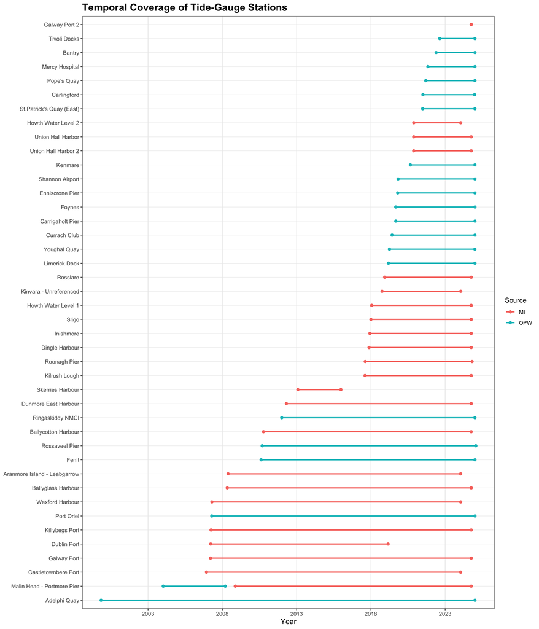

```r
station_coverage |>
  mutate(station_id = fct_reorder(station_id, first_obs)) |>
  ggplot(aes(y = station_id)) +
  geom_segment( aes(x = first_obs, xend = last_obs, yend = station_id, colour = source), linewidth = 1) +
  geom_point(aes(x = first_obs, colour=source), size = 1.8) +
  geom_point(aes(x = last_obs, colour=source), size = 1.8) +
  scale_x_datetime(date_breaks = "5 years", date_labels = "%Y") +
  labs(title = "Temporal Coverage of Tide-Gauge Stations", x = "Year", y = NULL, colour = "Source") +
  theme_bw() +
  theme(
    plot.title = element_text(size = 16, face = "bold"),
    axis.title.x = element_text(size = 12),
    axis.text.x = element_text(size = 9),
    axis.text.y = element_text(size = 9),
    panel.grid.major.y = element_line(linewidth = 0.3),
    panel.grid.minor = element_blank(),
    legend.position = "right")
```

The plot shows variation in the temporal coverage of the tide-gauge records, both between stations and between the MI and OPW data sources. Record lengths range from only a few years for some stations to more than two decades for the longest-running gauges.

The OPW contribution is particularly important for extending the geographical network with more recent observations. Many OPW stations begin around 2019–2021 and continue to the end of the study period. A smaller number have much longer records: Adelphi Quay extends back to around 2000, while Port Oriel, Rossaveel Pier and Fenit provide records extending back to approximately 2007–2011.

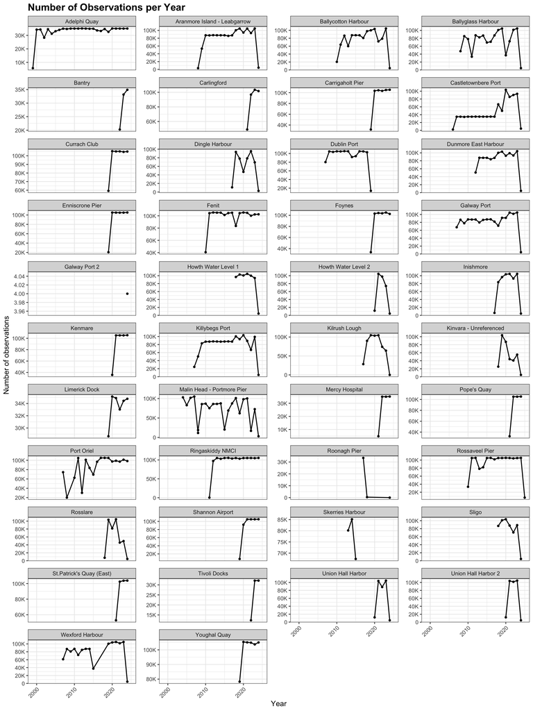

```r
observations_year <- da |>
  mutate(year = year(time)) |>
  count(source, st_id, station_id, year, name = "n")

observations_year |>
  ggplot(aes(x = year, y = n)) +
  geom_line(linewidth = 0.7) +
  geom_point(size = 1.2) +
  facet_wrap(~ station_id, scales = "free_y", ncol = 4) +
  scale_x_continuous(breaks = scales::pretty_breaks(n = 4)) +
  scale_y_continuous(
    labels = scales::label_number(scale_cut = scales::cut_short_scale()),
    breaks = scales::pretty_breaks(n = 4)) +
  labs(title = "Number of Observations per Year", x = "Year", y = "Number of observations") +
  theme_bw() +
  theme(
    plot.title = element_text(size = 16, face = "bold"),
    axis.title = element_text(size = 12),
    axis.text = element_text(size = 9),
    axis.text.x = element_text(angle = 45, hjust = 1),
    strip.text = element_text(size = 9),
    panel.spacing = unit(0.8, "lines"))
```

This plot provides a more detailed view of how the amount of available data varies through time within each station record. While the temporal-coverage plot shows when each station begins and ends, this figure shows that having a station record spanning a particular period does not necessarily mean that observations are equally complete throughout that period.

For many stations, the annual number of observations is relatively stable during the main part of the record. Several stations have approximately 90,000–105,000 observations per year, suggesting a high and reasonably consistent sampling frequency. Other stations have lower but similarly stable annual counts, which likely reflects differences in their underlying sampling frequency rather than necessarily poorer data quality.

There are, however, clear examples of substantial variation in data availability within individual records. Malin Head–Portmore Pier is particularly variable, with pronounced reductions in the number of observations in several years. Port Oriel, Skerries Harbour, Sligo, Inishmore and Ballyglass Harbour also show sizeable year-to-year changes. These reductions indicate periods of missing observations, changes in sampling frequency, or both, and warrant further investigation before modelling.

The very low counts occurring at the beginning or end of many station records should be interpreted differently. For example, a number of stations fall close to zero in their final year. These values do not necessarily represent poor-quality years; they can arise because the dataset contains only a partial calendar year at the start or end of the available record. This is particularly important for the most recent year in the dataset. Annual observation counts therefore need to be interpreted alongside the dates of the first and last observations.

## Sampling frequency

The plot above suggests that stations are not all recording observations at the same temporal resolution. Sampling frequency may also change through time at individual stations. The following calculations use the difference between consecutive observed timestamps to determine the most likely sampling frequency for each station.

```r
sampling_intervals <- da |>
  select(source, st_id, station_id, time) |>
  arrange(st_id, time) |>
  group_by(st_id) |>
  mutate(dtime = as.numeric(difftime( time, lag(time), units = "mins"))) |>
  ungroup() |>
  filter(!is.na(dtime), dtime > 0)
```

The table below contains the expected sampling interval for each station, along with the number of times that sampling interval was detected during the tide gauge record. The majority of stations (both MI and OPW) have an expected sampling interval of every five or six minutes, with a handful of stations that appear to have the slightly longer 15-minute sampling interval.

```r
station_sampling_frequency <- sampling_intervals |>
  count(source, st_id, station_id, dtime, name = "n_interval") |>
  group_by(source, st_id, station_id) |>
  slice_max(n_interval, n = 1, with_ties = FALSE) |>
  ungroup() |>
  rename(expected_interval_min = dtime) |>
  arrange(source, expected_interval_min, station_id)

station_sampling_frequency |>
  knitr::kable(digits = 2)
```

| source | st_id | station_id | expected_interval_min | n_interval |
| --- | --- | --- | --- | --- |
| MI | CastletownberePort | Castletownbere Port | 5 | 484054 |
| MI | DingleHarbour | Dingle Harbour | 5 | 435511 |
| MI | DublinPort | Dublin Port | 5 | 1219684 |
| MI | DunmoreEastHarbour | Dunmore East Harbour | 5 | 575059 |
| MI | GalwayPort2 | Galway Port 2 | 5 | 2 |
| MI | HowthWaterLevel1 | Howth Water Level 1 | 5 | 589983 |
| MI | HowthWaterLevel2 | Howth Water Level 2 | 5 | 291431 |
| MI | Inishmore | Inishmore | 5 | 562438 |
| MI | KilrushLough | Kilrush Lough | 5 | 506283 |
| MI | Kinvara-Unreferenced | Kinvara - Unreferenced | 5 | 359699 |
| MI | Rosslare | Rosslare | 5 | 396325 |
| MI | Sligo | Sligo | 5 | 436431 |
| MI | UnionHallHarbor | Union Hall Harbor | 5 | 312197 |
| MI | UnionHallHarbor2 | Union Hall Harbor 2 | 5 | 325896 |
| MI | AranmoreIsland-Leabgarrow | Aranmore Island - Leabgarrow | 6 | 775288 |
| MI | BallycottonHarbour | Ballycotton Harbour | 6 | 590498 |
| MI | BallyglassHarbour | Ballyglass Harbour | 6 | 746282 |
| MI | GalwayPort | Galway Port | 6 | 939418 |
| MI | KillybegsPort | Killybegs Port | 6 | 877520 |
| MI | MalinHead-PortmorePier | Malin Head - Portmore Pier | 6 | 712913 |
| MI | RoonaghPier | Roonagh Pier | 6 | 33822 |
| MI | SkerriesHarbour | Skerries Harbour | 6 | 231766 |
| MI | WexfordHarbour | Wexford Harbour | 6 | 685896 |
| OPW | Carlingford | Carlingford | 5 | 345933 |
| OPW | CarrigaholtPier | Carrigaholt Pier | 5 | 552960 |
| OPW | CurrachClub | Currach Club | 5 | 584283 |
| OPW | EnniscronePier | Enniscrone Pier | 5 | 545761 |
| OPW | Fenit | Fenit | 5 | 1471696 |
| OPW | Foynes | Foynes | 5 | 551961 |
| OPW | Kenmare | Kenmare | 5 | 456379 |
| OPW | MalinHead-PortmorePier | Malin Head - Portmore Pier | 5 | 411965 |
| OPW | PopesQuay | Pope’s Quay | 5 | 347910 |
| OPW | PortOriel | Port Oriel | 5 | 1447592 |
| OPW | RingaskiddyNMCI | Ringaskiddy NMCI | 5 | 1353652 |
| OPW | RossaveelPier | Rossaveel Pier | 5 | 1458814 |
| OPW | ShannonAirport | Shannon Airport | 5 | 520019 |
| OPW | StPatricksQuayEast | St.Patrick’s Quay (East) | 5 | 362750 |
| OPW | YoughalQuay | Youghal Quay | 5 | 602171 |
| OPW | AdelphiQuay | Adelphi Quay | 15 | 859864 |
| OPW | Bantry | Bantry | 15 | 88280 |
| OPW | LimerickDock | Limerick Dock | 15 | 200749 |
| OPW | MercyHospital | Mercy Hospital | 15 | 109955 |
| OPW | TivoliDocks | Tivoli Docks | 15 | 76099 |

This plot shows the median time interval between consecutive water-level observations for each station and year.

Most stations have a high and very consistent sampling frequency. A large proportion of the more recent records have a median sampling interval of approximately 5 minutes, while several of the longer-running MI stations initially recorded observations at approximately 6-minute intervals. Stations including Galway Port, Inishmore, Ballycotton Harbour, Ballyglass Harbour and Dunmore East Harbour show a clear transition from approximately 6-minute to 5-minute sampling in the later part of their records. These systematic shifts are likely to reflect changes in the data collection or recording regime rather than changes in data quality.

The figure identifies two conspicuous anomalies: Kilrush Lough and Roonagh Pier have extremely large median intervals in the final part of their records. These values are several orders of magnitude larger than those observed elsewhere and are unlikely to represent genuine sampling frequencies. Instead, they suggest that very few observations remain during those years, producing very large time gaps between consecutive measurements. These stations should therefore be examined when assessing missingness and deciding which years are sufficiently complete for analysis.

Malin Head–Portmore Pier also differs from most stations, showing some variation between approximately 5- and 6-minute intervals during the earlier portion of its record before settling at approximately 5 minutes. This could reflect changes in recording frequency or interruptions within the historical record.

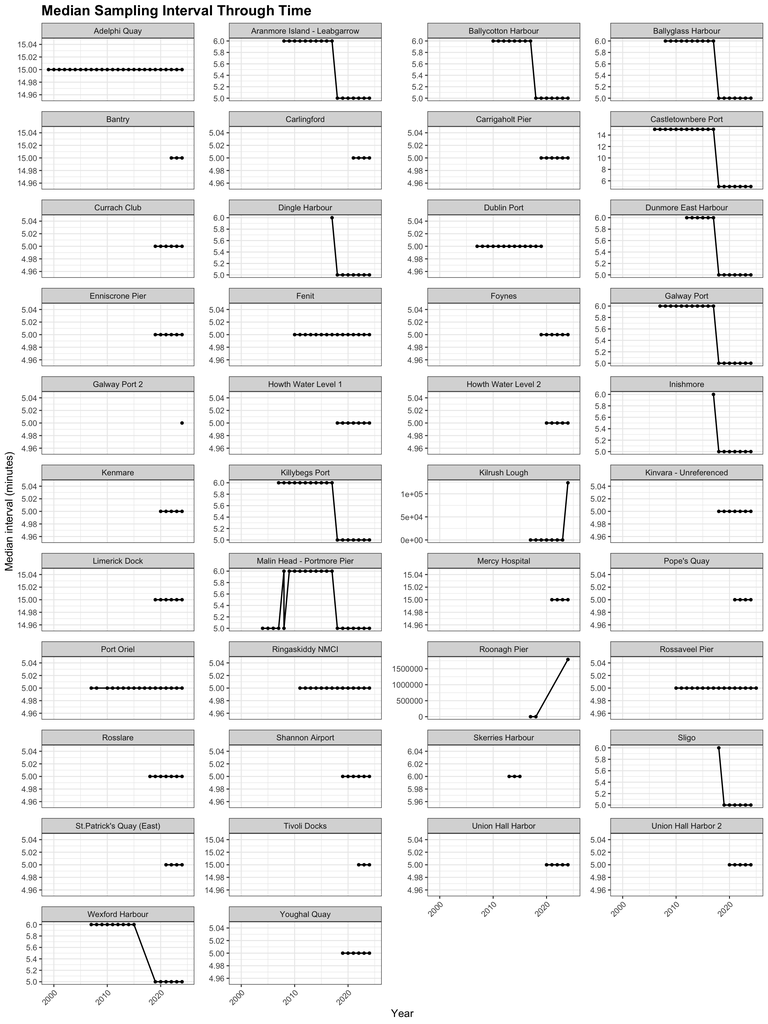

```r
sampling_year <- sampling_intervals |>
  mutate(year = year(time)) |>
  group_by(source, st_id, station_id, year) |>
  summarise(median_interval = median(dtime, na.rm = TRUE), .groups = "drop")

sampling_year |>
  ggplot(aes(x = year, y = median_interval, group = st_id)) +
  geom_line(linewidth = 0.7) +
  geom_point(size = 1.2) +
  facet_wrap(~ station_id, scales = "free_y", ncol = 4) +
  scale_x_continuous(breaks = scales::pretty_breaks(n = 4)) +
  scale_y_continuous(breaks = scales::pretty_breaks(n = 4)) +
  labs(title = "Median Sampling Interval Through Time", x = "Year", y = "Median interval (minutes)") +
  theme_bw() +
  theme(
    plot.title = element_text(size = 16, face = "bold"),
    axis.title = element_text(size = 12),
    axis.text = element_text(size = 9),
    axis.text.x = element_text(angle = 45, hjust = 1),
    strip.text = element_text(size = 9),
    panel.spacing = unit(0.8, "lines"))
```

## Missing data and gaps

A long record can still contain substantial periods with no observations. Consequently, both the duration and completeness of each record are examined.

A gap is defined relative to the station’s usual sampling interval. For example, if a station normally records every 10 minutes, an interval greater than 10 minutes indicates that at least one expected observation is absent.

The issue identified with Roonagh Pier in the above plot is explained here by the large gap in the record for this station. Roonagh Pier has an expected sampling interval of every six minutes, but has a gap in the sampling of approximately 2,486 days (or approximately 6.8 years).

Roonagh Pier is not the only tide gauge station with a large gap in its record. Stations such as Inishmore, Sligo, and Wexford Harbour also have large amounts of missing data. The difference, as we will see in subsequent plots, is that for the Roonagh Pier station, a large gap in the data is combined with a relatively short sampling time, whereas the other stations have longer sampling records.

```r
gap_data <- sampling_intervals |>
  left_join(
    station_sampling_frequency |>
      select(source, st_id, station_id, expected_interval_min),
    by = c("source", "st_id", "station_id")) |>
  mutate(
    is_gap = dtime > expected_interval_min,
    missing_intervals = pmax(round(dtime / expected_interval_min) - 1, 0))

gap_data |>
  filter(is_gap) |>
  select(source, station_id, st_id, time, dtime, expected_interval_min, missing_intervals) |>
  arrange(desc(dtime)) |>
  slice_head(n = 30) |>
  mutate(gap_hours = dtime / 60, gap_days = dtime / (60 * 24)) |>
  select(source, station_id, time, expected_interval_min, gap_hours, gap_days, missing_intervals) |>
  knitr::kable(digits = 2, format = "html", format.args = list(big.mark = ",")) |>
  kableExtra::kable_styling(full_width = TRUE, bootstrap_options = c("striped", "hover", "condensed")) |>
  kableExtra::scroll_box(height = "500px", fixed_thead = TRUE)
```

| source | station_id | time | expected_interval_min | gap_hours | gap_days | missing_intervals |
| --- | --- | --- | --- | --- | --- | --- |
| MI | Roonagh Pier | 2024-10-23 13:00:00 | 6 | 59,662.90 | 2,485.95 | 596,628 |
| MI | Wexford Harbour | 2019-01-09 15:35:00 | 6 | 31,507.58 | 1,312.82 | 315,075 |
| OPW | Port Oriel | 2010-05-28 13:50:00 | 5 | 19,419.00 | 809.12 | 233,027 |
| MI | Rosslare | 2023-07-12 09:15:00 | 5 | 9,552.50 | 398.02 | 114,629 |
| MI | Malin Head - Portmore Pier | 2023-01-27 12:45:00 | 6 | 7,977.08 | 332.38 | 79,770 |
| MI | Dingle Harbour | 2020-07-21 10:45:00 | 5 | 7,105.50 | 296.06 | 85,265 |
| MI | Killybegs Port | 2008-04-15 16:42:00 | 6 | 6,761.20 | 281.72 | 67,611 |
| MI | Castletownbere Port | 2019-07-09 11:15:00 | 5 | 6,377.83 | 265.74 | 76,533 |
| MI | Malin Head - Portmore Pier | 2016-03-18 11:42:00 | 6 | 6,293.90 | 262.25 | 62,938 |
| MI | Killybegs Port | 2024-10-03 13:40:00 | 6 | 6,263.83 | 260.99 | 62,637 |
| MI | Howth Water Level 1 | 2024-10-03 13:30:00 | 5 | 6,263.33 | 260.97 | 75,159 |
| MI | Galway Port | 2024-10-03 13:00:00 | 6 | 6,263.08 | 260.96 | 62,630 |
| MI | Dingle Harbour | 2024-10-03 12:30:00 | 5 | 6,262.83 | 260.95 | 75,153 |
| MI | Dunmore East Harbour | 2024-10-03 12:15:00 | 5 | 6,262.50 | 260.94 | 75,149 |
| MI | Inishmore | 2024-10-03 13:30:00 | 5 | 6,262.42 | 260.93 | 75,148 |
| MI | Malin Head - Portmore Pier | 2024-10-03 14:15:00 | 6 | 6,262.42 | 260.93 | 62,623 |
| MI | Ballyglass Harbour | 2024-10-03 10:50:00 | 6 | 6,262.33 | 260.93 | 62,622 |
| MI | Kilrush Lough | 2024-10-03 13:45:00 | 5 | 6,262.17 | 260.92 | 75,145 |
| MI | Union Hall Harbor | 2024-10-03 14:40:00 | 5 | 6,261.83 | 260.91 | 75,141 |
| MI | Ballycotton Harbour | 2024-10-03 09:55:00 | 6 | 6,261.58 | 260.90 | 62,615 |
| MI | Sligo | 2024-10-03 13:45:00 | 5 | 6,261.17 | 260.88 | 75,133 |
| MI | Rosslare | 2024-10-03 12:40:00 | 5 | 6,260.50 | 260.85 | 75,125 |
| MI | Union Hall Harbor 2 | 2024-10-03 15:30:00 | 5 | 6,242.75 | 260.11 | 74,912 |
| OPW | Port Oriel | 2012-12-14 16:20:00 | 5 | 6,129.00 | 255.38 | 73,547 |
| MI | Malin Head - Portmore Pier | 2008-11-13 15:06:00 | 6 | 5,911.10 | 246.30 | 59,110 |
| MI | Ballyglass Harbour | 2011-11-16 17:48:00 | 6 | 5,392.80 | 224.70 | 53,927 |
| MI | Aranmore Island - Leabgarrow | 2009-01-10 00:06:00 | 6 | 5,268.10 | 219.50 | 52,680 |
| MI | Kinvara - Unreferenced | 2023-06-20 15:30:00 | 5 | 5,162.00 | 215.08 | 61,943 |
| MI | Kinvara - Unreferenced | 2022-06-16 04:40:00 | 5 | 4,778.42 | 199.10 | 57,340 |
| MI | Ballyglass Harbour | 2021-04-21 08:55:00 | 6 | 4,302.58 | 179.27 | 43,025 |

This heatmap provides an assessment of data completeness within each station record, showing the percentage of expected observations that are available in each calendar year. Dark purple represents years approaching 100% completeness, while lighter blue, green and yellow indicate progressively less complete years. White areas correspond to periods outside the available station record and/or periods of missing data.

A strong feature of the plot is that many stations have very high completeness during the main portion of their records. For example, Adelphi Quay, Dublin Port, Fenit, Galway Port, Killybegs Port and Ringsaskiddy NMCI contain long sequences of predominantly dark-purple cells. This indicates that, once these stations were operational, most expected observations were available for many consecutive years.

Roonagh Pier, in particular is notable here. While previous checks did not flag Roonagh Pier as having fewer than three years of data, this heatmap shows us that it has two consecutive years of data, followed by a long gap, and then its final year of data is collected in 2024. This suggests that Roonagh Pier will not be a suitable station for further analysis.

Another prominent feature is the low completeness in 2024 for many stations, visible as the yellow or green column at the right-hand side of the heatmap. Because this occurs simultaneously across a large number of otherwise highly complete stations, it is much more likely to reflect a partial final year in the dataset than a widespread deterioration in station performance. The final calendar year should therefore not be interpreted in the same way as an incomplete year occurring in the middle of a station’s record.

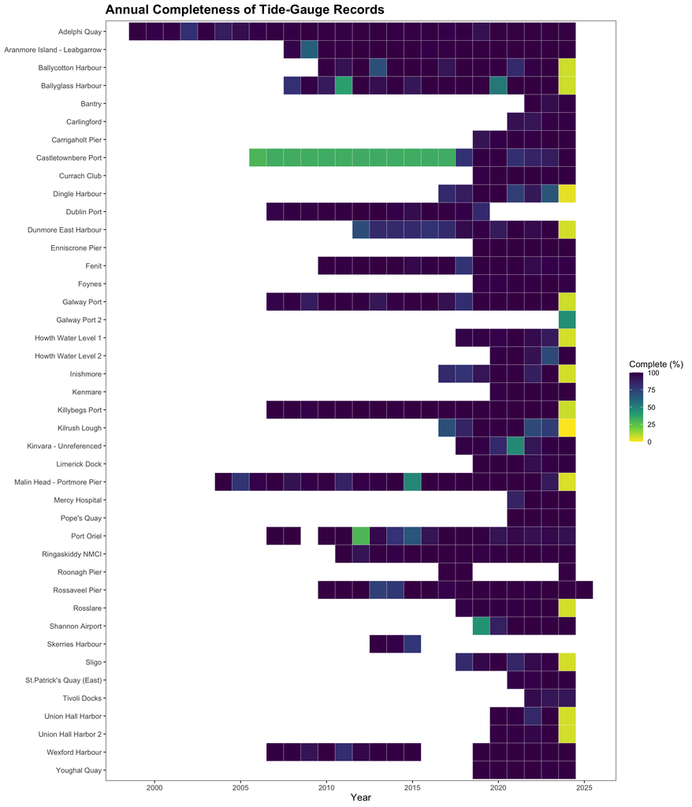

```r
annual_completeness <- da |>
  mutate(year = year(time)) |>
  group_by(source, st_id, station_id, year) |>
  summarise(
    first_obs_year = min(time, na.rm = TRUE),
    last_obs_year = max(time, na.rm = TRUE),
    n_observed = n(), .groups = "drop") |>
  left_join(
    station_sampling_frequency |>
      select(source, st_id, station_id, expected_interval_min),
    by = c("source", "st_id", "station_id")) |>
  mutate(
    active_minutes = as.numeric(difftime(last_obs_year, first_obs_year, units = "mins")),
    n_expected = floor(active_minutes / expected_interval_min) + 1,
    completeness =pmin(n_observed / n_expected, 1),
    completeness_percent = 100 * completeness)

annual_completeness |>
  mutate(station_id = fct_rev(factor(station_id))) |>
  ggplot(aes(x = year, y = station_id, fill = completeness_percent)) +
  geom_tile(colour = "white", linewidth = 0.1) +
  scale_fill_viridis_c(limits = c(0, 100),  direction = -1, name = "Complete (%)") +
  scale_x_continuous(breaks = scales::pretty_breaks(n = 8)) +
  labs(title = "Annual Completeness of Tide-Gauge Records", x = "Year",  y = NULL) +
  theme_bw() +
  theme(
    plot.title = element_text(size = 16, face = "bold"),
    axis.title.x = element_text(size = 12),
    axis.text.x = element_text(size = 9),
    axis.text.y = element_text(size = 9),
    panel.grid = element_blank(),
    legend.position = "right")
```

## Water-level observations

This plot compares the distribution of observed water levels across stations, with stations ordered by their median water level. The boxes represent the interquartile range, the central lines show the median, and the whiskers describe the spread of the observations beyond the central 50% of the data.

For the majority of stations, the distributions are broadly comparable. Median water levels are generally close to 0 m OD Malin, while most stations show similar variation above and below this level.

The two most striking stations are Galway Port 2 and Kinvara–Unreferenced. Galway Port 2 has an exceptionally narrow distribution centred at approximately −1 m OD Malin. From the previous plots, this station also contains extremely few observations, so its boxplot should not be interpreted as representative of a normal tidal distribution.

More importantly, Kinvara–Unreferenced is clearly separated from the remainder of the network, with observations centred at approximately −2.5 m OD Malin and a very narrow range. Its distribution is inconsistent with the other stations and suggests a possible issue with the vertical datum, station metadata, or water-level measurements. This provides strong justification for investigating Kinvara separately before including it in modelling alongside the other stations.

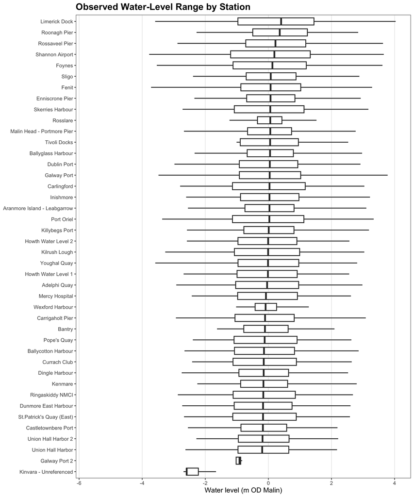

```r
water_level_summary <- da |>
  group_by(source, st_id, station_id) |>
  summarise(n = sum(!is.na(Water_Level_OD_Malin)),
    missing = sum(is.na(Water_Level_OD_Malin)),
    minimum = min(Water_Level_OD_Malin, na.rm = TRUE),
    q01 = quantile(Water_Level_OD_Malin, 0.01, na.rm = TRUE),
    q05 = quantile(Water_Level_OD_Malin, 0.05, na.rm = TRUE),
    median = median(Water_Level_OD_Malin, na.rm = TRUE),
    mean = mean(Water_Level_OD_Malin, na.rm = TRUE),
    q95 = quantile(Water_Level_OD_Malin, 0.95, na.rm = TRUE),
    q99 = quantile(Water_Level_OD_Malin, 0.99, na.rm = TRUE),
    maximum = max(Water_Level_OD_Malin, na.rm = TRUE),
    sd = sd(Water_Level_OD_Malin, na.rm = TRUE), .groups = "drop")


da |>
  filter(!is.na(Water_Level_OD_Malin)) |>
  mutate(station_id = fct_reorder(station_id, Water_Level_OD_Malin, median, na.rm = TRUE)) |>
  ggplot(aes(x = station_id, y = Water_Level_OD_Malin)) +
  geom_boxplot(outlier.shape = NA, linewidth = 0.7, width = 0.65) +
  coord_flip() +
  labs(title = "Observed Water-Level Range by Station", x = NULL, y = "Water level (m OD Malin)") +
  theme_bw() +
  theme(
    plot.title = element_text(size = 16, face = "bold"),
    axis.title.x = element_text(size = 12),
    axis.text.x = element_text(size = 9),
    axis.text.y = element_text(size = 9),
    panel.grid.major.y = element_blank(),
    panel.grid.minor = element_blank())
```

This plot shows the distribution of observed water levels at each tide-gauge station and provides a useful comparison of the shape, location and spread of the water-level records across the network.

For most stations, the distributions have the expected bimodal or weakly bimodal shape associated with tidal observations. The two broad peaks reflect the tendency for observations to accumulate around low and high stages of the tidal cycle, with comparatively less time spent around intermediate water levels. Although the precise location and separation of these peaks varies among stations, most distributions occupy a broadly similar range and appear physically plausible.

A few stations stand out from the general pattern. Galway Port 2 has an extremely concentrated distribution, which is consistent with the earlier finding that this station contains very few observations. Its apparent distribution therefore cannot be considered representative of the normal tidal behaviour at the location. Tivoli Docks also has an unusual distribution, with a pronounced narrow peak and a broader component extending towards higher water levels. These stations are to be removed because they have fewer than three years of observations, so further examination of these distributions is not necessary at this stage.

The most striking anomaly is Kinvara–Unreferenced. Unlike almost every other station, it does not display the broad tidal distribution expected from a continuously sampled water-level record. Instead, there is a very sharp concentration of observations at approximately −2.5 to −2.7 m OD Malin, accompanied by a much smaller and more diffuse distribution extending towards higher water levels. This explains why Kinvara appeared so clearly separated from the other stations in the preceding boxplot.

Importantly, this suggests that the Kinvara issue is not simply that the entire tidal record has been shifted vertically by a constant datum offset. If that were the only problem, we would still expect to see a reasonably broad, tidal-shaped distribution, just centred at a different elevation. The very large spike instead suggests that a substantial proportion of observations are concentrated at or very close to one particular value.

That pattern could arise from several data issues, including a repeated placeholder or default value, periods when the gauge became effectively fixed at one measurement, values introduced during missing-data processing, or a change in the way the Kinvara observations were recorded. The smaller distribution extending away from the spike may represent a subset of the record in which the gauge was behaving normally.

Overall, most stations show distributions consistent with continuously varying tidal water levels, while Kinvara–Unreferenced is a clear outlier in both the location and shape of its distribution. Plotting Kinvara through time and separating its distributions by year should tell us whether the spike corresponds to a particular period of the record and whether there is a usable portion of the station data that can be retained.

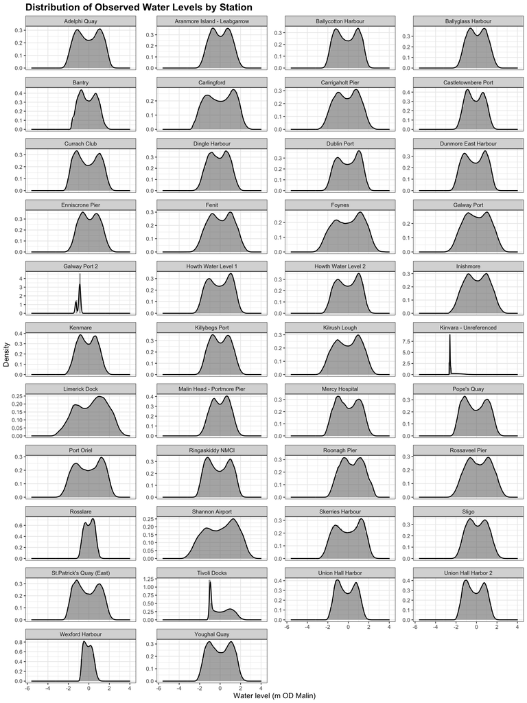

```r
da |>
  filter(!is.na(Water_Level_OD_Malin)) |>
  ggplot(aes(x = Water_Level_OD_Malin)) +
  geom_histogram(aes(y = after_stat(density)), bins = 60, alpha = 0.5) +
  geom_density(linewidth = 0.7, na.rm = TRUE) +
  facet_wrap(~ station_id, scales = "free_y", ncol = 4) +
  labs(title = "Distribution of Observed Water Levels by Station", x = "Water level (m OD Malin)", y = "Density") +
  theme_bw() +
  theme(
    plot.title = element_text(size = 16, face = "bold"),
    axis.title = element_text(size = 12),
    axis.text = element_text(size = 9),
    strip.text = element_text(size = 9),
    panel.spacing = unit(0.8, "lines"))
```

This year-by-year breakdown confirms that the unusual distribution observed for Kinvara–Unreferenced is persistent throughout the entire available record, rather than being caused by a single anomalous year or a short period of poor-quality observations.

From 2018 through 2024, each year shows a pronounced concentration of observations at approximately −2.5 m OD Malin. The frequency of observations at or very close to this value is much greater than at surrounding water levels, producing the large spike seen in the overall distribution. Although observations extend across a wider range of water levels, they do not form the broad, approximately bimodal tidal distributions expected at other stations.

The consistency of this feature across years is particularly important. If the unusual distribution were confined to one year, it might be possible to identify and remove a specific period of erroneous measurements while retaining the remainder of the station record. Instead, the same behaviour is present from the beginning to the end of the available Kinvara record. This suggests a systematic problem with the station data, rather than an isolated period of missingness or sensor malfunction.

There is consequently no clearly identifiable period within the available Kinvara record that can be considered representative of a normal continuous tidal time series. Kinvara–Unreferenced will therefore be excluded from the subsequent tidal analysis.

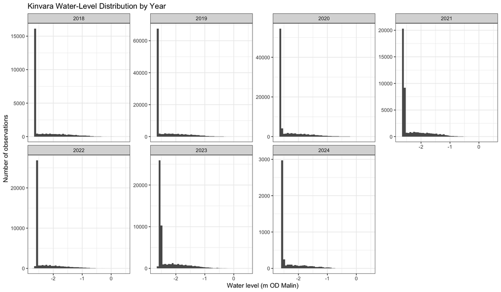

```r
kinvara <- da |>
  filter(st_id == "Kinvara-Unreferenced", !is.na(Water_Level_OD_Malin))

kinvara |>
  mutate(year = year(time)) |>
  ggplot(aes(x = Water_Level_OD_Malin)) +
  geom_histogram(bins = 50) +
  facet_wrap(~ year, scales = "free_y", ncol = 4) +
  labs(title = "Kinvara Water-Level Distribution by Year", x = "Water level (m OD Malin)", y = "Number of observations") +
  theme_bw()
```

## Quality control

The current analysis dataset is the `iteration_a_qc1` dataset and so it contains only observations that have passed quality control.

```r
qc_summary <- da |>
  count(QC_Flag, name = "n") |>
  mutate(percent = 100 * n / sum(n))

qc_summary |>
  knitr::kable(digits = 2, format.args = list( big.mark = ","))
```

| QC_Flag | n | percent |
| --- | --- | --- |
| 1 | 29,303,019 | 100 |

## Station metadata

Station metadata are examined before analysis to identify missing coordinates, duplicate locations, inconsistent station identifiers and potential differences in reference datum.

```r
station_coordinates <- da |>
  distinct(source, station_id, st_id, latitude, longitude) |>
  arrange(source, station_id)

missing_coordinates <- station_coordinates |>
  filter(is.na(latitude) | is.na(longitude))

if (nrow(missing_coordinates) > 0) {
  missing_coordinates |>
    knitr::kable()

} else {
  cat("No stations have missing latitude or longitude.")
}
```

```
#| No stations have missing latitude or longitude.
```

```r
coordinate_check <- da |>
  filter(!is.na(latitude), !is.na(longitude)) |>
  distinct(st_id, latitude, longitude) |>
  count(st_id, name = "n_coordinate_pairs") |>
  filter(n_coordinate_pairs > 1)

if (nrow(coordinate_check) > 0) {
  coordinate_check |>
    knitr::kable()

} else {

  cat("Every station is associated with a single coordinate pair.")
}
```

```
#| Every station is associated with a single coordinate pair.
```

```r
station_id_check <- da |>
  distinct(station_id, st_id)

duplicate_station_ids <- station_id_check |>
  count(st_id, name = "n_station_names") |>
  filter(n_station_names > 1)

if (nrow(duplicate_station_ids) > 0) {
  station_id_check |>
    semi_join(duplicate_station_ids, by = "st_id") |>
    arrange(st_id, station_id) |>
    knitr::kable()

} else {
  cat("Each st_id corresponds to a single station name.")
}
```

```
#| Each st_id corresponds to a single station name.
```

## Stations retained for analysis

The exploratory analysis above identified three criteria that determine whether a station is retained for the subsequent tidal analysis.

First, stations must have a minimum record span of three years. Second, the available observations must provide a sufficiently continuous and usable record; a record spanning three years or more is not considered sufficient if the observations are separated by substantial gaps that prevent the construction of the required analysis windows. Finally, stations with persistent anomalies in their observed water-level distributions are excluded where the available record cannot be considered representative of a normal tidal time series.

Below is the final list of stations to be retained for analysis, followed by a table detailing the excluded stations and the reason for their exclusion.

```r
station_coverage <- station_coverage |>
  mutate(
    include_analysis = case_when(
      record_years < MIN_RECORD_YEARS ~ FALSE,
      st_id == "RoonaghPier" ~ FALSE,
      st_id == "Kinvara-Unreferenced" ~ FALSE,
      TRUE ~ TRUE
    ),
    exclusion_reason = case_when(
      record_years < MIN_RECORD_YEARS ~ "Less than 3 years of available data",
      st_id == "RoonaghPier" ~ "Insufficient consecutive usable data due to a large gap in the record",
      st_id == "Kinvara-Unreferenced" ~ "Persistent anomalous water-level distribution",
      TRUE ~ NA_character_
    )
  )

included_stations <- station_coverage |>
  filter(include_analysis) |>
  arrange(source, station_id)

included_stations |>
  select(source, station_id, st_id, first_obs, last_obs, record_years, n_observations) |>
  knitr::kable(
    digits = 2,
    format = "html",
    format.args = list(big.mark = ",")
  ) |>
  kableExtra::kable_styling(
    full_width = TRUE,
    bootstrap_options = c("striped", "hover", "condensed")
  ) |>
  kableExtra::scroll_box(
    height = "500px",
    fixed_thead = TRUE
  )
```

| source | station_id | st_id | first_obs | last_obs | record_years | n_observations |
| --- | --- | --- | --- | --- | --- | --- |
| MI | Aranmore Island - Leabgarrow | AranmoreIsland-Leabgarrow | 2008-05-21 16:06:00 | 2024-01-16 12:00:00 | 15.65 | 1,362,123 |
| MI | Ballycotton Harbour | BallycottonHarbour | 2010-10-07 15:06:00 | 2024-10-03 10:50:00 | 13.99 | 1,134,948 |
| MI | Ballyglass Harbour | BallyglassHarbour | 2008-04-30 20:06:00 | 2024-10-03 11:30:00 | 16.43 | 1,255,857 |
| MI | Castletownbere Port | CastletownberePort | 2006-12-06 14:15:00 | 2024-01-16 12:45:00 | 17.11 | 879,113 |
| MI | Dingle Harbour | DingleHarbour | 2017-11-16 13:00:00 | 2024-10-03 12:30:00 | 6.88 | 475,871 |
| MI | Dublin Port | DublinPort | 2007-03-20 06:55:00 | 2019-02-27 11:35:00 | 11.94 | 1,220,775 |
| MI | Dunmore East Harbour | DunmoreEastHarbour | 2012-04-23 09:06:00 | 2024-10-03 12:45:00 | 12.45 | 1,081,626 |
| MI | Galway Port | GalwayPort | 2007-03-15 18:48:00 | 2024-10-03 13:00:00 | 17.55 | 1,487,725 |
| MI | Howth Water Level 1 | HowthWaterLevel1 | 2018-01-19 07:42:00 | 2024-10-03 13:30:00 | 6.71 | 603,617 |
| MI | Howth Water Level 2 | HowthWaterLevel2 | 2020-11-20 12:45:00 | 2024-01-16 14:25:00 | 3.15 | 292,716 |
| MI | Inishmore | Inishmore | 2017-12-06 12:18:00 | 2024-10-03 14:05:00 | 6.83 | 596,629 |
| MI | Killybegs Port | KillybegsPort | 2007-03-28 14:36:00 | 2024-10-03 14:20:00 | 17.52 | 1,413,738 |
| MI | Kilrush Lough | KilrushLough | 2017-08-09 09:42:00 | 2024-10-03 14:20:00 | 7.15 | 569,747 |
| MI | Malin Head - Portmore Pier | MalinHead-PortmorePier | 2008-11-13 15:06:00 | 2024-10-03 14:50:00 | 15.89 | 1,150,807 |
| MI | Rosslare | Rosslare | 2018-12-05 10:10:00 | 2024-10-03 15:05:00 | 5.83 | 396,961 |
| MI | Sligo | Sligo | 2018-01-01 00:00:00 | 2024-10-03 15:05:00 | 6.76 | 543,407 |
| MI | Union Hall Harbor | UnionHallHarbor | 2020-11-20 12:20:00 | 2024-10-03 14:40:00 | 3.87 | 313,224 |
| MI | Union Hall Harbor 2 | UnionHallHarbor2 | 2020-11-19 09:05:00 | 2024-10-03 15:30:00 | 3.87 | 326,983 |
| MI | Wexford Harbour | WexfordHarbour | 2007-04-19 15:18:00 | 2024-01-16 13:35:00 | 16.74 | 1,206,644 |
| OPW | Adelphi Quay | AdelphiQuay | 1999-11-02 16:00:00 | 2024-12-31 23:30:00 | 25.16 | 859,950 |
| OPW | Carlingford | Carlingford | 2021-07-02 12:30:00 | 2024-12-24 00:30:00 | 3.48 | 350,976 |
| OPW | Carrigaholt Pier | CarrigaholtPier | 2019-09-04 00:00:00 | 2024-12-31 23:45:00 | 5.33 | 553,172 |
| OPW | Currach Club | CurrachClub | 2019-06-04 14:25:00 | 2024-12-31 23:30:00 | 5.58 | 584,321 |
| OPW | Enniscrone Pier | EnniscronePier | 2019-10-21 15:00:00 | 2024-12-31 23:30:00 | 5.20 | 546,186 |
| OPW | Fenit | Fenit | 2010-08-12 15:00:00 | 2024-12-31 23:45:00 | 14.39 | 1,474,460 |
| OPW | Foynes | Foynes | 2019-09-04 00:00:00 | 2024-12-31 23:30:00 | 5.33 | 552,020 |
| OPW | Kenmare | Kenmare | 2020-08-28 00:00:00 | 2024-12-31 23:45:00 | 4.34 | 456,421 |
| OPW | Limerick Dock | LimerickDock | 2019-03-08 11:45:00 | 2024-12-31 23:45:00 | 5.82 | 200,905 |
| OPW | Malin Head - Portmore Pier | MalinHead-PortmorePier | 2004-01-09 00:15:00 | 2008-03-12 08:00:00 | 4.17 | 411,988 |
| OPW | Mercy Hospital | MercyHospital | 2021-11-03 16:00:00 | 2024-12-31 23:45:00 | 3.16 | 109,986 |
| OPW | Pope's Quay | PopesQuay | 2021-09-10 15:45:00 | 2024-12-31 23:45:00 | 3.31 | 347,931 |
| OPW | Port Oriel | PortOriel | 2007-04-17 08:50:00 | 2024-12-31 23:45:00 | 17.71 | 1,451,526 |
| OPW | Ringaskiddy NMCI | RingaskiddyNMCI | 2011-12-31 00:15:00 | 2024-12-31 23:45:00 | 13.00 | 1,353,756 |
| OPW | Rossaveel Pier | RossaveelPier | 2010-09-06 08:30:00 | 2025-01-24 02:15:00 | 14.38 | 1,458,887 |
| OPW | Shannon Airport | ShannonAirport | 2019-10-31 17:30:00 | 2024-12-31 23:45:00 | 5.17 | 520,076 |
| OPW | St.Patrick's Quay (East) | StPatricksQuayEast | 2021-06-26 00:00:00 | 2024-12-31 18:00:00 | 3.52 | 362,905 |
| OPW | Youghal Quay | YoughalQuay | 2019-04-01 13:00:00 | 2024-12-31 01:00:00 | 5.75 | 602,500 |

```r
excluded_stations <- station_coverage |>
  filter(!include_analysis) |>
  arrange(source, station_id)

excluded_stations |>
  select(source, station_id, st_id, first_obs, last_obs, record_years, exclusion_reason) |>
  knitr::kable(digits = 2, format = "html", format.args = list(big.mark = ",")) |>
  kableExtra::kable_styling(full_width = TRUE, bootstrap_options = c("striped", "hover", "condensed"))
```

| source | station_id | st_id | first_obs | last_obs | record_years | exclusion_reason |
| --- | --- | --- | --- | --- | --- | --- |
| MI | Galway Port 2 | GalwayPort2 | 2024-10-03 12:30:00 | 2024-10-03 13:10:00 | 0.00 | Less than 3 years of available data |
| MI | Kinvara - Unreferenced | Kinvara-Unreferenced | 2018-10-03 19:10:00 | 2024-01-17 14:15:00 | 5.29 | Persistent anomalous water-level distribution |
| MI | Roonagh Pier | RoonaghPier | 2017-08-14 11:00:00 | 2024-10-23 13:05:00 | 7.19 | Insufficient consecutive usable data due to a large gap in the record |
| MI | Skerries Harbour | SkerriesHarbour | 2013-01-31 13:00:00 | 2015-12-25 04:24:00 | 2.90 | Less than 3 years of available data |
| OPW | Bantry | Bantry | 2022-05-25 10:30:00 | 2024-12-31 23:45:00 | 2.61 | Less than 3 years of available data |
| OPW | Tivoli Docks | TivoliDocks | 2022-08-19 10:00:00 | 2024-12-31 23:30:00 | 2.37 | Less than 3 years of available data |

```r
stations <- included_stations |>
  pull(st_id) |>
  sort()

saveRDS(stations, here::here("rds", "stations-all_iteration_a.rds"))

writeLines(stations, here::here("templates", "stations-all_iteration_a.txt"))

saveRDS(station_coverage, here::here("rds", "station-coverage_iteration_a.rds"))

write_csv(station_coverage, here::here("outputs", "station-coverage_iteration_a.csv"))

saveRDS(annual_completeness, here::here("rds", "station-completeness_iteration_a.rds"))

write_csv(annual_completeness, here::here("outputs", "station-completeness_iteration_a.csv"))

write_csv(station_sampling_frequency, here::here( "outputs", "station-sampling-frequency_iteration_a.csv"))
```